# Trp53cor1 KO vs WT (brain)

This file shows the wt-v-ko comparison for Trp53cor1.

Cuff overview:

```
## CuffSet instance with:
##   2 samples
##   26754 genes
##   77524 isoforms
##   0 TSS
##   23066 CDS
##   0 promoters
##   0 splicing
##   19954 relCDS
```

# QC

## Dispersion

Dispersion plot for genes in cuff: (Overdispersion can lead to innacurate quants)

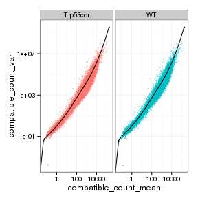

## Cross-replicate variability (fpkmSCVplot)

Differences in CV 2 can result in lower numbers of differentially expressed genes due to a higher degree of variability between replicate fpkm estimates.

Genes:

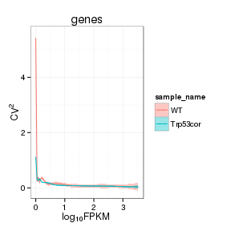

Isoforms:

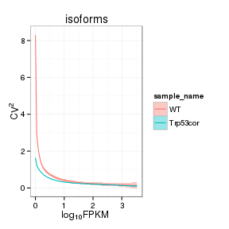

## MvA plot

[output not shown]

### MvA plot counts

[output not shown]

## Scatterplot matrix

[figure not shown]

## Distributions

### Boxplots

Boxplot (genes)

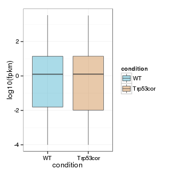

Boxplot (genes, replicates)

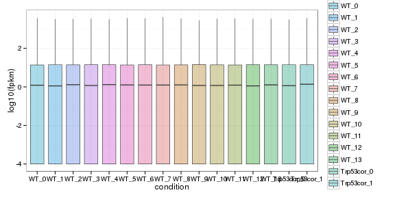

Boxplot (isoforms)

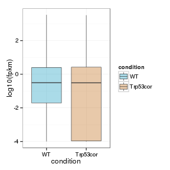

Boxplot (isoforms, replicates)

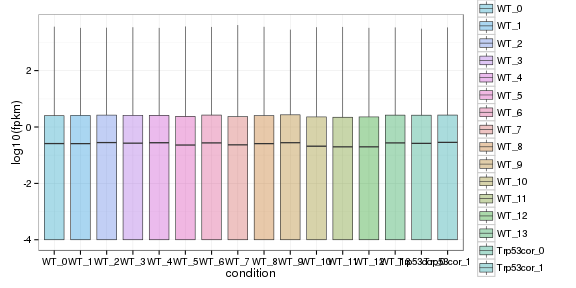

### Density

Density (genes)

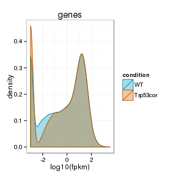

Density (genes, replicates)

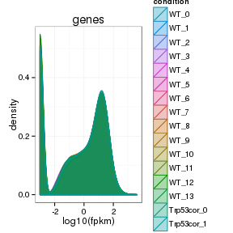

## Clustering

### Replicate Clusters

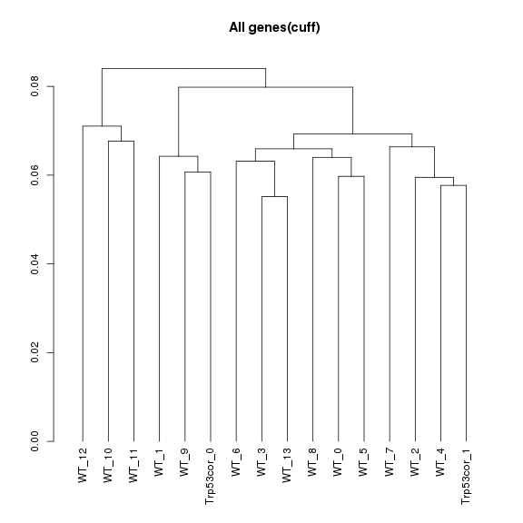

### PCA (genes)

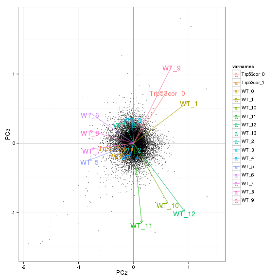

### MDS (genes)

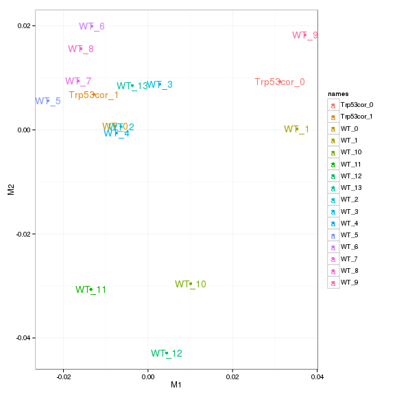

# KO assessment

## Endogenous lncRNA expression

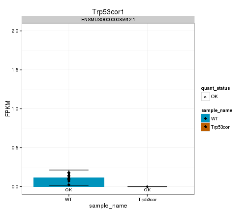

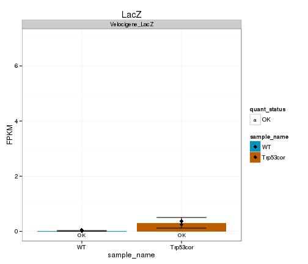

## Digital Genotyping (LacZ vs Endogenous lncRNA and Sex)

Eif2s3y is a y-expressed gene, Xist is an x-expressed gene Expression plot (endogenous linc, lacZ, Y-expressed gene):

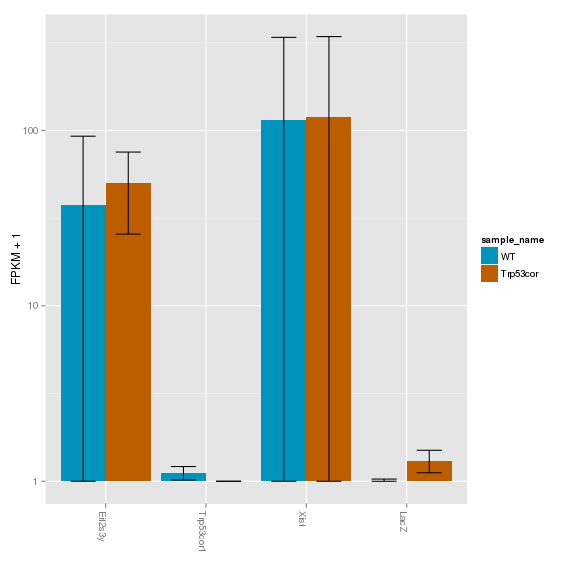

Expression heatmap:

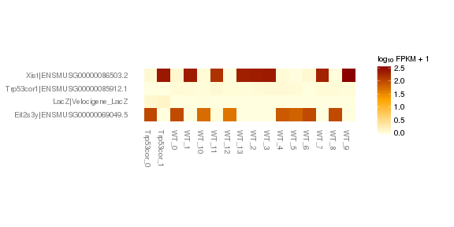

### Track visualization

[output not shown]

# Differential Analysis

## Differential Genes

[output not shown]

[output not shown]

[output not shown]

There are 0 significantly differentially expressed genes. They are:

[1] “No sig genes!”

Expression heatmap of sigGenes

[output not shown]

Foldchange heatmap of sigGenes

[output not shown]

Now, look at genes that are detectably expressed (FPKM>0.5, yes I know it should be 1), and log2foldchange>2 in any direction: 26 genes

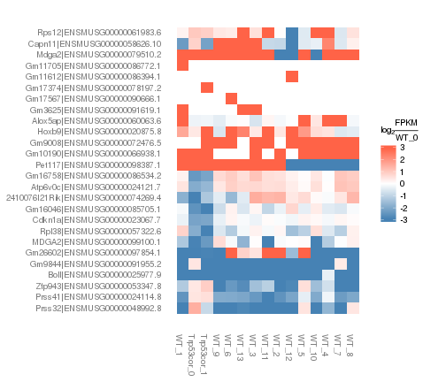

[output not shown]

[figure not shown]

### Expression-level/significance relationship

Scatter plot of significant genes only:

[output not shown]

Volcano Plot

[output not shown]

Volcano plot with significant genes only:

[output not shown]

### Differential Isoforms between conditions

Per isoform difference between conditions:

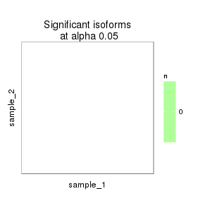

These isoforms are:

[1] “no sig isoforms”

DE isoform heatmap

```
## [1] "no sig isoforms"
```

Isoform foldchange heatmap by isoform:

```
## [1] "no sig isoforms"
```

# Gene/Pathway Analysis

## GSEA

Enrichment and zscores are calculated based on expression in KO vs WT (fpkmKO/fpkmWT), so genes that are down regulated in KO are shown in blue, while upregulation is shown in red.

KO/WT Blue = down in KO Red = Up in KO

Biocarta enrichment:

[output not shown]

Biocarta zscore:

[output not shown]

[output not shown]

[output not shown]

[output not shown]

Reactome enrichment:

[output not shown]

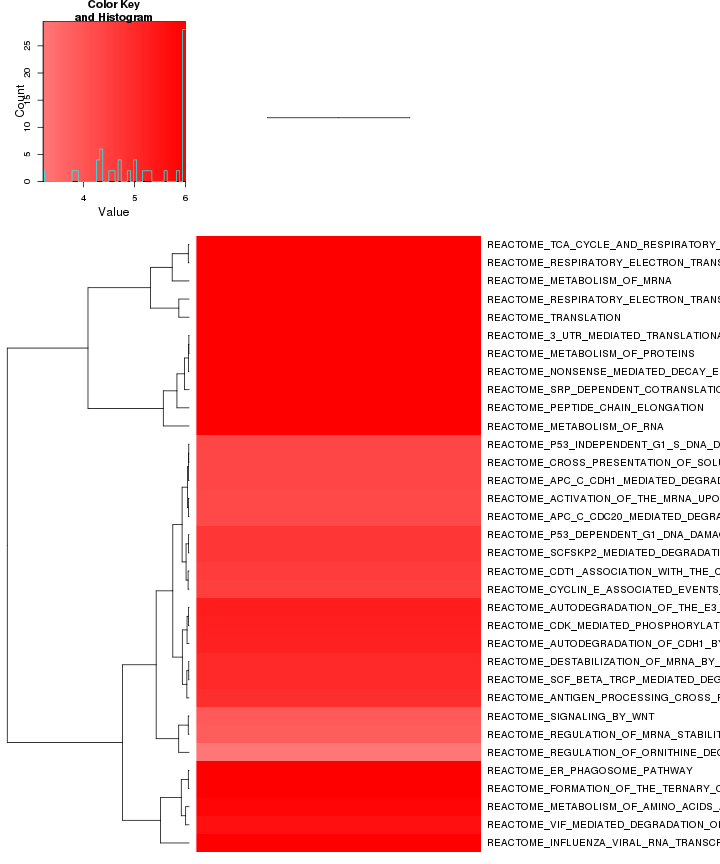

Reactome zscore:

[output not shown]

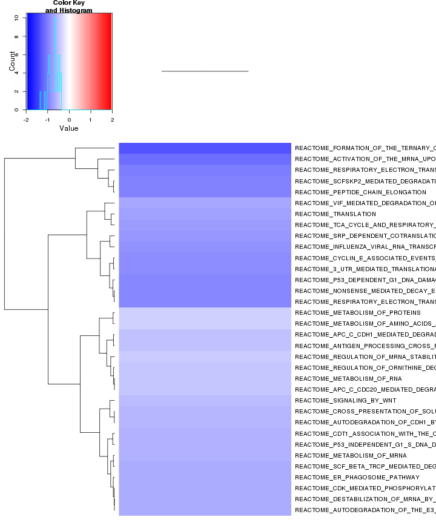

Kegg enrichment:

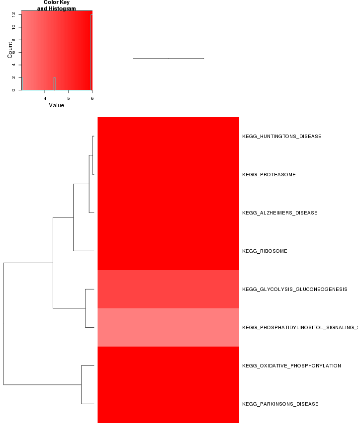

Kegg zscore:

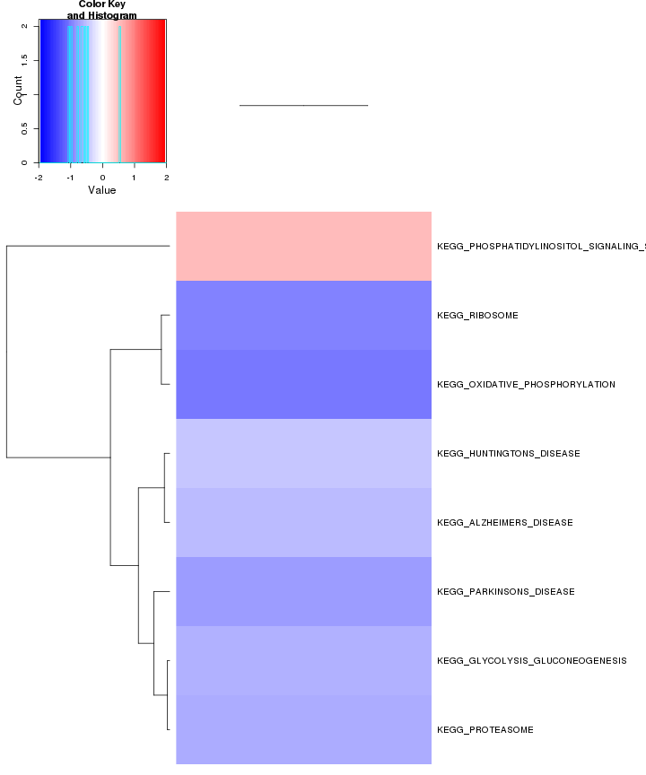

p53 enrichment:

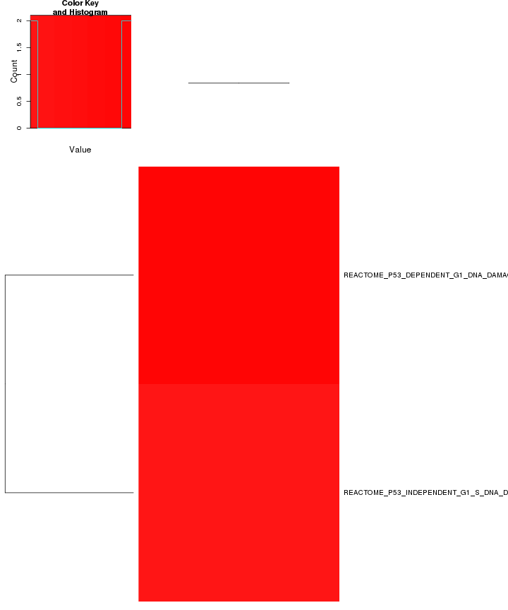

p53 zscore:

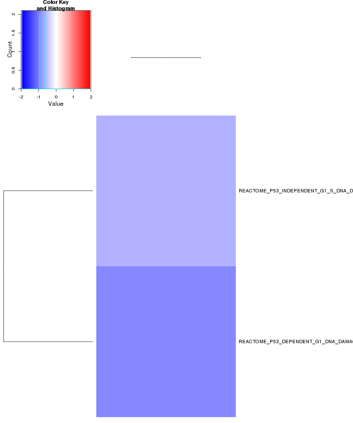

Oncogene enrichment:

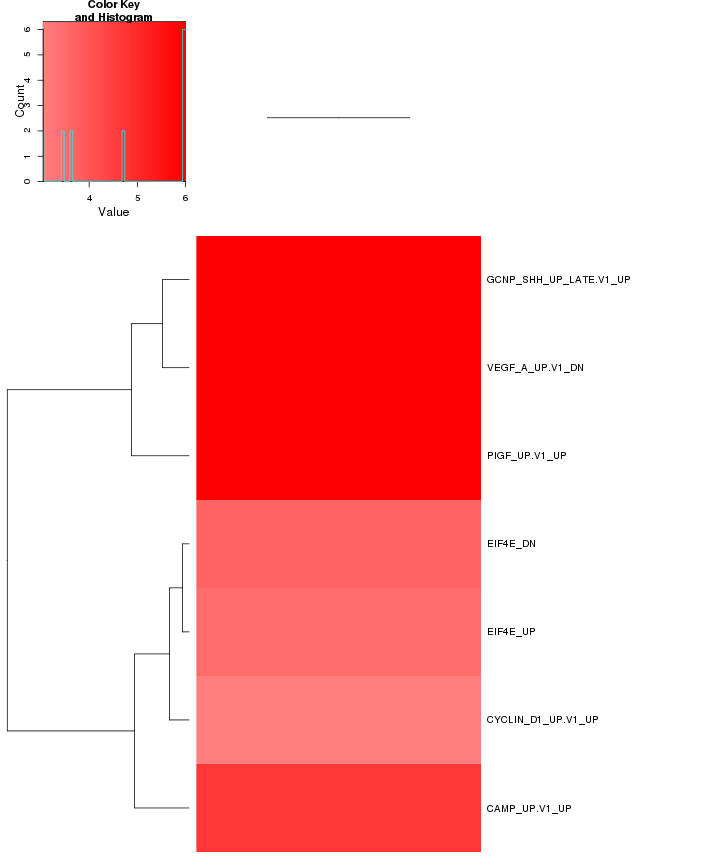

Oncogene zscore:

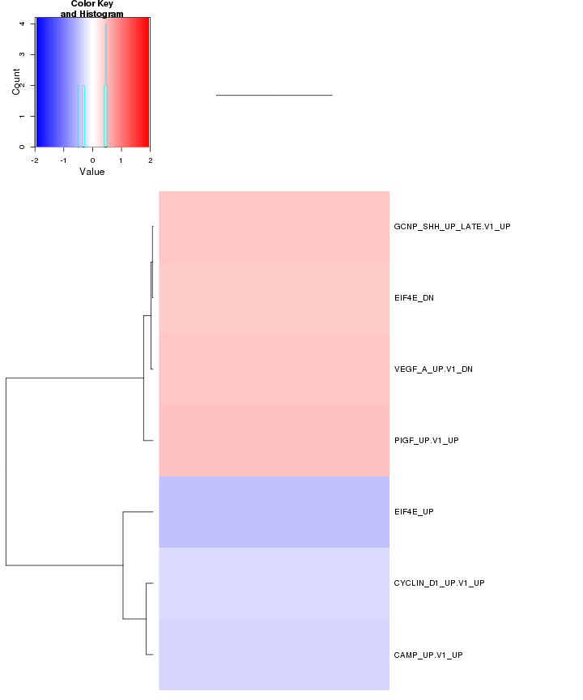

Jacks enrichment

```
## [1] "Not enough significant categories to print a heatmap!"
```

Jacks zscore

```
## [1] "Not enough significant categories to print a heatmap!"
```

Consistantly changing genes enrichment:

[output not shown]

[figure not shown]

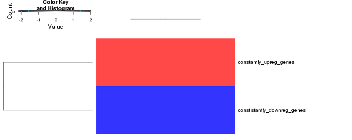

All enrichment

There are 462 categories enriched (p<0.0001). They are:

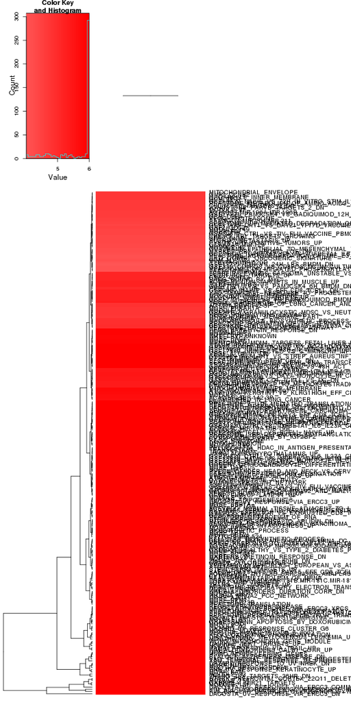

ALL zscore:

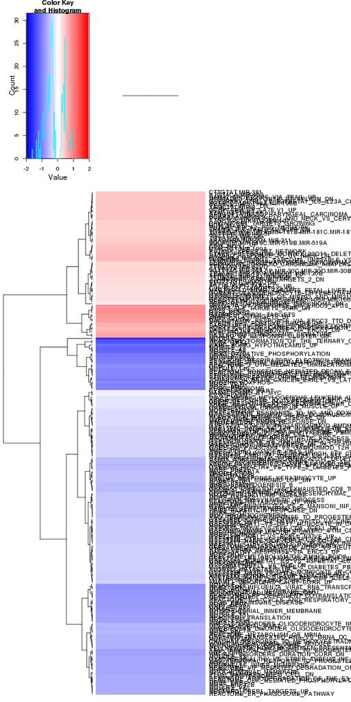

## GO enrichment

[output not shown]

[output not shown]

[output not shown]

[output not shown]

[output not shown]

[output not shown]

[output not shown]

[output not shown]

[output not shown]

[output not shown]

[output not shown]

[output not shown]

[output not shown]

[output not shown]

[output not shown]

[output not shown]

[output not shown]

[output not shown]

# Cis vs Trans (locally)

log2 Foldchange and test statistic are calculated with the ratio of fpkm(KO)/fpkm(WT), thus the test_stat is positive if a gene is higher in the KO and negative if a gene has lower expression in the KO

The pvalue for genes significantly regulated in a region this size is: 1

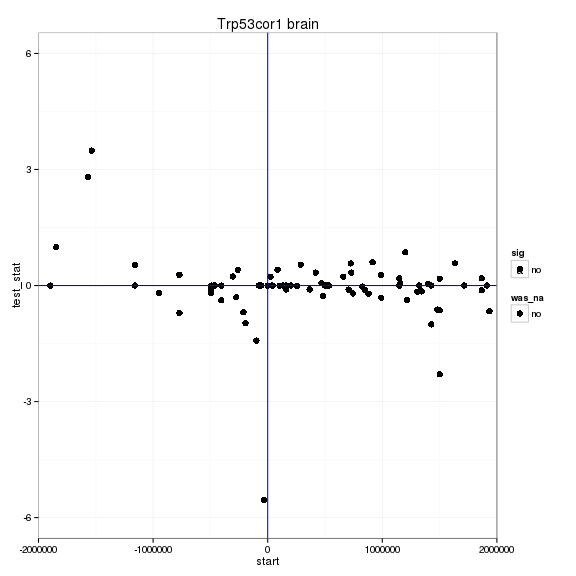

# Notes

## Samples used are:

|  | 11 |
| --- | --- |
| 1 | abundances.cxb |
| 2 | abundances.cxb |
| 3 | abundances.cxb |
| 4 | abundances.cxb |
| 5 | abundances.cxb |
| 6 | abundances.cxb |
| 7 | abundances.cxb |
| 8 | abundances.cxb |
| 9 | abundances.cxb |
| 10 | abundances.cxb |
| 11 | abundances.cxb |
| 12 | abundances.cxb |
| 13 | abundances.cxb |
| 14 | abundances.cxb |
| 15 | abundances.cxb |
| 16 | abundances.cxb |

## Replicates

|  | file | sample_name | replicate | rep_name | total_mass | norm_mass | internal_scale | external_scale |
| --- | --- | --- | --- | --- | --- | --- | --- | --- |
| 1 | /n/rinn_data1/seq/lgoff/Projects/BrainMap/data/quants/JR753/abundances.cxb | WT | 0 | WT_0 | 39331900.00 | 31980100.00 | 1.28 | 1.00 |
| 2 | /n/rinn_data1/seq/lgoff/Projects/BrainMap/data/quants/JR750/abundances.cxb | WT | 1 | WT_1 | 36031100.00 | 31980100.00 | 1.11 | 1.00 |
| 3 | /n/rinn_data1/seq/lgoff/Projects/BrainMap/data/quants/JR771/abundances.cxb | WT | 2 | WT_2 | 38857100.00 | 31980100.00 | 1.24 | 1.00 |
| 4 | /n/rinn_data1/seq/lgoff/Projects/BrainMap/data/quants/JR755/abundances.cxb | WT | 3 | WT_3 | 41811300.00 | 31980100.00 | 1.30 | 1.00 |
| 5 | /n/rinn_data1/seq/lgoff/Projects/BrainMap/data/quants/JR811/abundances.cxb | WT | 4 | WT_4 | 38172800.00 | 31980100.00 | 1.21 | 1.00 |
| 6 | /n/rinn_data1/seq/lgoff/Projects/BrainMap/data/quants/JR768/abundances.cxb | WT | 5 | WT_5 | 28375200.00 | 31980100.00 | 0.90 | 1.00 |
| 7 | /n/rinn_data1/seq/lgoff/Projects/BrainMap/data/quants/JR761/abundances.cxb | WT | 6 | WT_6 | 31706200.00 | 31980100.00 | 0.98 | 1.00 |
| 8 | /n/rinn_data1/seq/lgoff/Projects/BrainMap/data/quants/JR815/abundances.cxb | WT | 7 | WT_7 | 29733100.00 | 31980100.00 | 0.93 | 1.00 |
| 9 | /n/rinn_data1/seq/lgoff/Projects/BrainMap/data/quants/JR789/abundances.cxb | WT | 8 | WT_8 | 27681500.00 | 31980100.00 | 0.87 | 1.00 |
| 10 | /n/rinn_data1/seq/lgoff/Projects/BrainMap/data/quants/JR748/abundances.cxb | WT | 9 | WT_9 | 32367000.00 | 31980100.00 | 0.97 | 1.00 |
| 11 | /n/rinn_data1/seq/lgoff/Projects/BrainMap/data/quants/JR716/abundances.cxb | WT | 10 | WT_10 | 26144700.00 | 31980100.00 | 0.82 | 1.00 |
| 12 | /n/rinn_data1/seq/lgoff/Projects/BrainMap/data/quants/JR717/abundances.cxb | WT | 11 | WT_11 | 25565400.00 | 31980100.00 | 0.81 | 1.00 |
| 13 | /n/rinn_data1/seq/lgoff/Projects/BrainMap/data/quants/JR719/abundances.cxb | WT | 12 | WT_12 | 22697800.00 | 31980100.00 | 0.69 | 1.00 |
| 14 | /n/rinn_data1/seq/lgoff/Projects/BrainMap/data/quants/JR756/abundances.cxb | WT | 13 | WT_13 | 38948900.00 | 31980100.00 | 1.23 | 1.00 |
| 15 | /n/rinn_data1/seq/lgoff/Projects/BrainMap/data/quants/JR749/abundances.cxb | Trp53cor | 0 | Trp53cor_0 | 31241000.00 | 31980100.00 | 0.95 | 1.00 |
| 16 | /n/rinn_data1/seq/lgoff/Projects/BrainMap/data/quants/JR814/abundances.cxb | Trp53cor | 1 | Trp53cor_1 | 31403400.00 | 31980100.00 | 1.00 | 1.00 |

## Run Info

[output not shown]